# Salary Prediction

In this project, we use supervised learning models to predict salaries using given features. Furthermore, we will analyze top factors that influence salary.

## Contents

- [Part 1: Data Exploration](#Part-1:-Data-Exploration)
- [Part 2: Feature Preprocessing](#Part-2:-Feature-Preprocessing)
- [Part 3: Model Selection and Results Evaluation](#Part-3:-Model-Selection-and-Result-Evaluation)
- [Part 4: Feature Importance Evaluation](#Part-4:-Feature-Importance-Evaluation)
- [Part 5: Model Training and Predicting Result](#Part-5:-Model-Training-and-Predicting-Result)

# Part 1: Data Exploration

### Part 1.1: Understand the Raw Dataset

```python
import warnings
warnings.filterwarnings('ignore') # Remove irrelevant warnings from console log

import pandas as pd
import numpy as np
pd.set_option('display.max_columns', None)

from sklearn.metrics import mean_absolute_error
from sklearn.metrics import mean_squared_error

# Read the training data
train_fea_ori = pd.read_csv('data/train_features_2013-03-07.csv')
train_sal_ori = pd.read_csv('data/train_salaries_2013-03-07.csv')
test_fea = pd.read_csv('data/test_features_2013-03-07.csv')
```

```python
# Using part of data to give a faster computation time, will use entire data for the finalized model
train_fea = train_fea_ori[:10000]
train_sal = train_sal_ori[:10000]

# y is the column of true value from training data
y = train_sal['salary']
y_all = train_sal_ori['salary']
```

```python
print 'Feature num of rows: ' + str(train_fea.shape[0]) # row count
print 'Feature num of columns: ' + str(train_fea.shape[1]) # col count
print 'Salary num of rows: ' + str(train_sal.shape[0]) # row count
print 'Salary num of columns: ' + str(train_sal.shape[1]) # col count
```

```
Feature num of rows: 10000
Feature num of columns: 8
Salary num of rows: 10000
Salary num of columns: 2
```

```python
# Check the data shape to see the categorical data value needs further cleaning
train_fea['industry'][0]
```

```
'HEALTH'
```

### Part 1.2: Understand the features

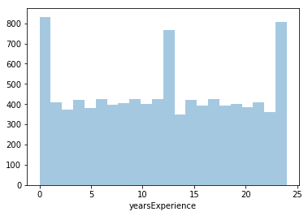

```python
%matplotlib inline
import matplotlib.pyplot as plt
import seaborn as sb

# Visualize how different data distributed
sb.distplot(train_fea['yearsExperience'], kde=False)
```

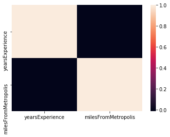

```python
# Using statistical idea to see whether data has correlation, if so, we can drop some features
corr = train_fea[['yearsExperience', 'milesFromMetropolis']].corr()
sb.heatmap(corr)
```

# Part 2: Feature Preprocessing

```python
# Drop some useless columns
to_drop = ['jobId']
train_fea_space = train_fea.drop(to_drop, axis = 1)

# Using one-hot encoding for categorical data
train_fea_space_ohe = pd.get_dummies(train_fea_space, columns = ['industry', 'degree', 'major', 'jobType', 'companyId'])

# Converts data frame to its Numpy-array representation.
X = train_fea_space_ohe.as_matrix().astype(np.float)

# Using all training data where X_all is all features and apply one-hot encoding
train_fea_space_ori = train_fea_ori.drop(to_drop, axis = 1)
train_fea_space_ohe_all = pd.get_dummies(train_fea_space_ori, columns = ['industry','degree', 'major', 'jobType', 'companyId'])

# Converts data frame to its Numpy-array representation.
X_all = train_fea_space_ohe_all.as_matrix().astype(np.float)
train_fea_space_ohe_all.shape
```

```
(1000000, 94)
```

```python
train_fea_space_ohe
```

|  | yearsExperience | milesFromMetropolis | industry_AUTO | industry_EDUCATION | industry_FINANCE | industry_HEALTH | industry_OIL | industry_SERVICE | industry_WEB | degree_BACHELORS | degree_DOCTORAL | degree_HIGH_SCHOOL | degree_MASTERS | degree_NONE | major_BIOLOGY | major_BUSINESS | major_CHEMISTRY | major_COMPSCI | major_ENGINEERING | major_LITERATURE | major_MATH | major_NONE | major_PHYSICS | jobType_CEO | jobType_CFO | jobType_CTO | jobType_JANITOR | jobType_JUNIOR | jobType_MANAGER | … |
| --- | --- | --- | --- | --- | --- | --- | --- | --- | --- | --- | --- | --- | --- | --- | --- | --- | --- | --- | --- | --- | --- | --- | --- | --- | --- | --- | --- | --- | --- | --- |
| 0 | 10 | 83 | 0 | 0 | 0 | 1 | 0 | 0 | 0 | 0 | 0 | 0 | 1 | 0 | 0 | 0 | 0 | 0 | 0 | 0 | 1 | 0 | 0 | 0 | 1 | 0 | 0 | 0 | 0 | … |
| 1 | 3 | 73 | 0 | 0 | 0 | 0 | 0 | 0 | 1 | 0 | 0 | 1 | 0 | 0 | 0 | 0 | 0 | 0 | 0 | 0 | 0 | 1 | 0 | 1 | 0 | 0 | 0 | 0 | 0 | … |
| 2 | 10 | 38 | 0 | 0 | 0 | 1 | 0 | 0 | 0 | 0 | 1 | 0 | 0 | 0 | 0 | 0 | 0 | 0 | 0 | 0 | 0 | 0 | 1 | 0 | 0 | 0 | 0 | 0 | 0 | … |
| 3 | 8 | 17 | 1 | 0 | 0 | 0 | 0 | 0 | 0 | 0 | 1 | 0 | 0 | 0 | 0 | 0 | 1 | 0 | 0 | 0 | 0 | 0 | 0 | 0 | 0 | 0 | 0 | 0 | 1 | … |
| 4 | 8 | 16 | 0 | 0 | 1 | 0 | 0 | 0 | 0 | 1 | 0 | 0 | 0 | 0 | 0 | 0 | 0 | 0 | 0 | 0 | 0 | 0 | 1 | 0 | 0 | 0 | 0 | 0 | 0 | … |
| 5 | 2 | 31 | 0 | 0 | 1 | 0 | 0 | 0 | 0 | 0 | 1 | 0 | 0 | 0 | 0 | 0 | 0 | 1 | 0 | 0 | 0 | 0 | 0 | 0 | 0 | 0 | 0 | 0 | 1 | … |
| 6 | 23 | 24 | 0 | 0 | 0 | 1 | 0 | 0 | 0 | 0 | 0 | 0 | 0 | 1 | 0 | 0 | 0 | 0 | 0 | 0 | 0 | 1 | 0 | 0 | 1 | 0 | 0 | 0 | 0 | … |
| 7 | 9 | 70 | 0 | 1 | 0 | 0 | 0 | 0 | 0 | 1 | 0 | 0 | 0 | 0 | 0 | 0 | 1 | 0 | 0 | 0 | 0 | 0 | 0 | 0 | 0 | 0 | 0 | 1 | 0 | … |
| 8 | 1 | 54 | 0 | 1 | 0 | 0 | 0 | 0 | 0 | 0 | 0 | 1 | 0 | 0 | 0 | 0 | 0 | 0 | 0 | 0 | 0 | 1 | 0 | 0 | 0 | 0 | 1 | 0 | 0 | … |
| 9 | 17 | 68 | 1 | 0 | 0 | 0 | 0 | 0 | 0 | 1 | 0 | 0 | 0 | 0 | 0 | 0 | 1 | 0 | 0 | 0 | 0 | 0 | 0 | 0 | 0 | 0 | 0 | 0 | 0 | … |
| 10 | 24 | 30 | 0 | 0 | 0 | 1 | 0 | 0 | 0 | 0 | 0 | 1 | 0 | 0 | 0 | 0 | 0 | 0 | 0 | 0 | 0 | 1 | 0 | 0 | 0 | 0 | 1 | 0 | 0 | … |
| 11 | 7 | 79 | 0 | 1 | 0 | 0 | 0 | 0 | 0 | 0 | 0 | 0 | 1 | 0 | 0 | 0 | 0 | 0 | 0 | 0 | 0 | 0 | 1 | 1 | 0 | 0 | 0 | 0 | 0 | … |
| 12 | 8 | 29 | 0 | 0 | 0 | 0 | 1 | 0 | 0 | 0 | 0 | 0 | 0 | 1 | 0 | 0 | 0 | 0 | 0 | 0 | 0 | 1 | 0 | 0 | 0 | 0 | 0 | 1 | 0 | … |
| 13 | 21 | 26 | 0 | 0 | 1 | 0 | 0 | 0 | 0 | 0 | 0 | 0 | 1 | 0 | 0 | 0 | 0 | 0 | 0 | 0 | 1 | 0 | 0 | 0 | 0 | 0 | 0 | 1 | 0 | … |
| 14 | 21 | 81 | 1 | 0 | 0 | 0 | 0 | 0 | 0 | 0 | 0 | 0 | 0 | 1 | 0 | 0 | 0 | 0 | 0 | 0 | 0 | 1 | 0 | 0 | 0 | 0 | 1 | 0 | 0 | … |
| 15 | 13 | 8 | 0 | 0 | 0 | 0 | 0 | 1 | 0 | 0 | 0 | 0 | 1 | 0 | 1 | 0 | 0 | 0 | 0 | 0 | 0 | 0 | 0 | 0 | 0 | 1 | 0 | 0 | 0 | … |
| 16 | 1 | 91 | 0 | 0 | 0 | 0 | 0 | 1 | 0 | 0 | 0 | 0 | 1 | 0 | 0 | 0 | 0 | 0 | 0 | 0 | 0 | 0 | 1 | 0 | 0 | 0 | 0 | 1 | 0 | … |
| 17 | 23 | 43 | 0 | 0 | 0 | 0 | 0 | 1 | 0 | 0 | 0 | 0 | 1 | 0 | 0 | 0 | 0 | 0 | 0 | 1 | 0 | 0 | 0 | 0 | 0 | 0 | 0 | 0 | 0 | … |
| 18 | 23 | 66 | 0 | 0 | 0 | 0 | 0 | 1 | 0 | 0 | 0 | 0 | 1 | 0 | 0 | 0 | 0 | 0 | 0 | 1 | 0 | 0 | 0 | 1 | 0 | 0 | 0 | 0 | 0 | … |
| 19 | 9 | 99 | 0 | 1 | 0 | 0 | 0 | 0 | 0 | 0 | 0 | 0 | 1 | 0 | 0 | 0 | 0 | 0 | 0 | 0 | 0 | 0 | 1 | 1 | 0 | 0 | 0 | 0 | 0 | … |
| 20 | 11 | 96 | 0 | 0 | 0 | 0 | 0 | 1 | 0 | 0 | 0 | 0 | 0 | 1 | 0 | 0 | 0 | 0 | 0 | 0 | 0 | 1 | 0 | 0 | 0 | 0 | 1 | 0 | 0 | … |
| 21 | 14 | 62 | 1 | 0 | 0 | 0 | 0 | 0 | 0 | 0 | 0 | 0 | 0 | 1 | 0 | 0 | 0 | 0 | 0 | 0 | 0 | 1 | 0 | 0 | 0 | 0 | 0 | 1 | 0 | … |
| 22 | 18 | 69 | 0 | 0 | 0 | 1 | 0 | 0 | 0 | 1 | 0 | 0 | 0 | 0 | 0 | 0 | 0 | 0 | 0 | 1 | 0 | 0 | 0 | 0 | 0 | 0 | 0 | 1 | 0 | … |
| 23 | 20 | 63 | 0 | 0 | 0 | 1 | 0 | 0 | 0 | 0 | 0 | 0 | 0 | 1 | 0 | 0 | 0 | 0 | 0 | 0 | 0 | 1 | 0 | 0 | 0 | 0 | 0 | 1 | 0 | … |
| 24 | 12 | 8 | 0 | 0 | 0 | 0 | 0 | 0 | 1 | 1 | 0 | 0 | 0 | 0 | 0 | 0 | 0 | 0 | 0 | 0 | 0 | 1 | 0 | 1 | 0 | 0 | 0 | 0 | 0 | … |
| 25 | 9 | 70 | 1 | 0 | 0 | 0 | 0 | 0 | 0 | 1 | 0 | 0 | 0 | 0 | 0 | 0 | 1 | 0 | 0 | 0 | 0 | 0 | 0 | 0 | 1 | 0 | 0 | 0 | 0 | … |
| 26 | 24 | 40 | 1 | 0 | 0 | 0 | 0 | 0 | 0 | 1 | 0 | 0 | 0 | 0 | 0 | 0 | 0 | 1 | 0 | 0 | 0 | 0 | 0 | 1 | 0 | 0 | 0 | 0 | 0 | … |
| 27 | 9 | 6 | 1 | 0 | 0 | 0 | 0 | 0 | 0 | 0 | 0 | 0 | 1 | 0 | 0 | 1 | 0 | 0 | 0 | 0 | 0 | 0 | 0 | 0 | 0 | 1 | 0 | 0 | 0 | … |
| 28 | 20 | 23 | 0 | 0 | 1 | 0 | 0 | 0 | 0 | 0 | 0 | 1 | 0 | 0 | 0 | 0 | 0 | 0 | 0 | 0 | 0 | 1 | 0 | 0 | 0 | 0 | 1 | 0 | 0 | … |
| 29 | 1 | 9 | 0 | 1 | 0 | 0 | 0 | 0 | 0 | 0 | 1 | 0 | 0 | 0 | 0 | 1 | 0 | 0 | 0 | 0 | 0 | 0 | 0 | 0 | 0 | 0 | 0 | 0 | 0 | … |
| ... | ... | ... | ... | ... | ... | ... | ... | ... | ... | ... | ... | ... | ... | ... | ... | ... | ... | ... | ... | ... | ... | ... | ... | ... | ... | ... | ... | ... | ... | … |
| 9970 | 23 | 99 | 0 | 0 | 0 | 1 | 0 | 0 | 0 | 1 | 0 | 0 | 0 | 0 | 0 | 0 | 0 | 0 | 0 | 0 | 0 | 0 | 1 | 1 | 0 | 0 | 0 | 0 | 0 | … |
| 9971 | 16 | 13 | 0 | 0 | 0 | 0 | 0 | 1 | 0 | 0 | 0 | 1 | 0 | 0 | 0 | 0 | 0 | 0 | 0 | 0 | 0 | 1 | 0 | 0 | 0 | 0 | 1 | 0 | 0 | … |
| 9972 | 22 | 90 | 0 | 0 | 0 | 0 | 0 | 0 | 1 | 0 | 0 | 1 | 0 | 0 | 0 | 0 | 0 | 0 | 0 | 0 | 0 | 1 | 0 | 0 | 0 | 0 | 1 | 0 | 0 | … |
| 9973 | 2 | 93 | 0 | 0 | 1 | 0 | 0 | 0 | 0 | 0 | 0 | 0 | 1 | 0 | 0 | 0 | 1 | 0 | 0 | 0 | 0 | 0 | 0 | 0 | 0 | 0 | 0 | 0 | 0 | … |
| 9974 | 15 | 54 | 0 | 1 | 0 | 0 | 0 | 0 | 0 | 0 | 0 | 0 | 1 | 0 | 0 | 0 | 0 | 0 | 0 | 0 | 0 | 0 | 1 | 0 | 0 | 0 | 0 | 1 | 0 | … |
| 9975 | 18 | 32 | 1 | 0 | 0 | 0 | 0 | 0 | 0 | 0 | 0 | 1 | 0 | 0 | 0 | 0 | 0 | 0 | 0 | 0 | 0 | 1 | 0 | 1 | 0 | 0 | 0 | 0 | 0 | … |
| 9976 | 0 | 90 | 0 | 1 | 0 | 0 | 0 | 0 | 0 | 0 | 0 | 0 | 1 | 0 | 0 | 0 | 1 | 0 | 0 | 0 | 0 | 0 | 0 | 0 | 0 | 0 | 0 | 0 | 0 | … |
| 9977 | 18 | 75 | 0 | 1 | 0 | 0 | 0 | 0 | 0 | 0 | 0 | 0 | 0 | 1 | 0 | 0 | 0 | 0 | 0 | 0 | 0 | 1 | 0 | 0 | 0 | 0 | 0 | 0 | 0 | … |
| 9978 | 21 | 63 | 0 | 0 | 0 | 0 | 0 | 1 | 0 | 1 | 0 | 0 | 0 | 0 | 0 | 0 | 0 | 0 | 0 | 0 | 1 | 0 | 0 | 0 | 0 | 0 | 0 | 0 | 0 | … |
| 9979 | 24 | 95 | 0 | 0 | 1 | 0 | 0 | 0 | 0 | 0 | 0 | 1 | 0 | 0 | 0 | 0 | 0 | 0 | 0 | 0 | 0 | 1 | 0 | 0 | 0 | 1 | 0 | 0 | 0 | … |
| 9980 | 8 | 46 | 0 | 0 | 1 | 0 | 0 | 0 | 0 | 0 | 0 | 0 | 1 | 0 | 0 | 0 | 0 | 1 | 0 | 0 | 0 | 0 | 0 | 0 | 1 | 0 | 0 | 0 | 0 | … |
| 9981 | 8 | 52 | 0 | 1 | 0 | 0 | 0 | 0 | 0 | 0 | 1 | 0 | 0 | 0 | 0 | 0 | 0 | 0 | 1 | 0 | 0 | 0 | 0 | 0 | 0 | 1 | 0 | 0 | 0 | … |
| 9982 | 7 | 8 | 0 | 1 | 0 | 0 | 0 | 0 | 0 | 0 | 0 | 0 | 0 | 1 | 0 | 0 | 0 | 0 | 0 | 0 | 0 | 1 | 0 | 0 | 0 | 0 | 1 | 0 | 0 | … |
| 9983 | 11 | 73 | 0 | 0 | 0 | 0 | 1 | 0 | 0 | 1 | 0 | 0 | 0 | 0 | 0 | 0 | 0 | 1 | 0 | 0 | 0 | 0 | 0 | 0 | 0 | 0 | 0 | 1 | 0 | … |
| 9984 | 17 | 42 | 1 | 0 | 0 | 0 | 0 | 0 | 0 | 0 | 0 | 1 | 0 | 0 | 0 | 0 | 0 | 0 | 0 | 0 | 0 | 1 | 0 | 0 | 1 | 0 | 0 | 0 | 0 | … |
| 9985 | 14 | 5 | 0 | 0 | 0 | 1 | 0 | 0 | 0 | 0 | 0 | 0 | 0 | 1 | 0 | 0 | 0 | 0 | 0 | 0 | 0 | 1 | 0 | 1 | 0 | 0 | 0 | 0 | 0 | … |
| 9986 | 21 | 13 | 0 | 0 | 1 | 0 | 0 | 0 | 0 | 0 | 0 | 0 | 0 | 1 | 0 | 0 | 0 | 0 | 0 | 0 | 0 | 1 | 0 | 0 | 0 | 0 | 0 | 0 | 0 | … |
| 9987 | 24 | 68 | 0 | 0 | 0 | 1 | 0 | 0 | 0 | 0 | 0 | 0 | 1 | 0 | 0 | 0 | 0 | 0 | 0 | 1 | 0 | 0 | 0 | 0 | 1 | 0 | 0 | 0 | 0 | … |
| 9988 | 16 | 67 | 0 | 0 | 0 | 0 | 0 | 0 | 1 | 1 | 0 | 0 | 0 | 0 | 0 | 0 | 1 | 0 | 0 | 0 | 0 | 0 | 0 | 0 | 0 | 0 | 0 | 0 | 0 | … |
| 9989 | 17 | 32 | 0 | 1 | 0 | 0 | 0 | 0 | 0 | 1 | 0 | 0 | 0 | 0 | 0 | 1 | 0 | 0 | 0 | 0 | 0 | 0 | 0 | 0 | 0 | 0 | 0 | 1 | 0 | … |
| 9990 | 12 | 48 | 0 | 0 | 0 | 0 | 0 | 1 | 0 | 0 | 1 | 0 | 0 | 0 | 0 | 0 | 0 | 0 | 0 | 0 | 0 | 0 | 1 | 0 | 0 | 1 | 0 | 0 | 0 | … |
| 9991 | 8 | 90 | 0 | 0 | 0 | 0 | 1 | 0 | 0 | 0 | 0 | 1 | 0 | 0 | 0 | 0 | 0 | 0 | 0 | 0 | 0 | 1 | 0 | 0 | 0 | 0 | 1 | 0 | 0 | … |
| 9992 | 2 | 74 | 0 | 1 | 0 | 0 | 0 | 0 | 0 | 0 | 0 | 0 | 0 | 1 | 0 | 0 | 0 | 0 | 0 | 0 | 0 | 1 | 0 | 0 | 0 | 0 | 0 | 0 | 0 | … |
| 9993 | 15 | 53 | 1 | 0 | 0 | 0 | 0 | 0 | 0 | 0 | 0 | 0 | 1 | 0 | 0 | 0 | 0 | 0 | 0 | 0 | 1 | 0 | 0 | 1 | 0 | 0 | 0 | 0 | 0 | … |
| 9994 | 12 | 62 | 0 | 1 | 0 | 0 | 0 | 0 | 0 | 0 | 0 | 0 | 0 | 1 | 0 | 0 | 0 | 0 | 0 | 0 | 0 | 1 | 0 | 0 | 0 | 1 | 0 | 0 | 0 | … |
| 9995 | 3 | 76 | 0 | 0 | 0 | 0 | 1 | 0 | 0 | 0 | 1 | 0 | 0 | 0 | 0 | 0 | 0 | 0 | 0 | 0 | 0 | 1 | 0 | 0 | 1 | 0 | 0 | 0 | 0 | … |
| 9996 | 12 | 73 | 0 | 0 | 0 | 0 | 1 | 0 | 0 | 0 | 0 | 0 | 1 | 0 | 1 | 0 | 0 | 0 | 0 | 0 | 0 | 0 | 0 | 0 | 0 | 0 | 0 | 0 | 0 | … |
| 9997 | 11 | 34 | 0 | 0 | 0 | 1 | 0 | 0 | 0 | 0 | 0 | 0 | 1 | 0 | 0 | 0 | 0 | 0 | 0 | 0 | 0 | 1 | 0 | 0 | 0 | 0 | 0 | 0 | 0 | … |
| 9998 | 21 | 15 | 0 | 0 | 1 | 0 | 0 | 0 | 0 | 0 | 0 | 0 | 0 | 1 | 0 | 0 | 0 | 0 | 0 | 0 | 0 | 1 | 0 | 0 | 0 | 0 | 1 | 0 | 0 | … |
| 9999 | 7 | 67 | 0 | 0 | 0 | 1 | 0 | 0 | 0 | 0 | 1 | 0 | 0 | 0 | 0 | 0 | 0 | 0 | 0 | 0 | 0 | 0 | 1 | 0 | 0 | 0 | 0 | 0 | 0 | … |

10000 rows × 94 columns

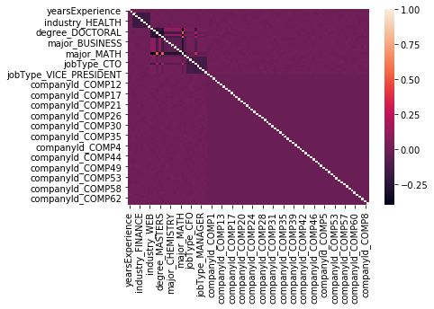

```python
# Check correlation again after one-hot encoding
corr = train_fea_space_ohe.corr()
sb.heatmap(corr)
```

```python
from sklearn.preprocessing import StandardScaler
scaler = StandardScaler()

# Scaling data for regression
X = scaler.fit_transform(X)
print 'Feature space holds %d observations and %d features' % X.shape
```

```
Feature space holds 10000 observations and 94 features
```

```python
X
```

```
array([[-0.26441536,  1.16569885, -0.40698528, ..., -0.12751534,
        -0.1187263 , -0.13189957],
       [-1.23383219,  0.81966888, -0.40698528, ..., -0.12751534,
        -0.1187263 , -0.13189957],
       [-0.26441536, -0.39143603, -0.40698528, ..., -0.12751534,
        -0.1187263 , -0.13189957],
       ...,
       [-0.12592725, -0.52984802, -0.40698528, ..., -0.12751534,
        -0.1187263 , -0.13189957],
       [ 1.25895394, -1.18730496, -0.40698528, ..., -0.12751534,
        -0.1187263 , -0.13189957],
       [-0.67987972,  0.6120509 , -0.40698528, ..., -0.12751534,
        -0.1187263 , -0.13189957]])
```

# Part 3: Model Selection and Result Evaluation

### Part 3.1: K-fold Cross-Validation

```python
from sklearn.cross_validation import KFold

# This function performs 5-fold cross-validation to show the predicted salary.
# It tracks the y-prediction result of each iteration
# In the end, it returns the array of y_pred as the result of all the 5-fold.
def run_cv(X, y, regr_class, **kwargs):
    # Construct a kfolds object
    kf = KFold(len(y),n_folds = 5,shuffle=True)
    y_pred = y.copy()
    regr = regr_class(**kwargs)
    # Iterate through folds
    for train_index, test_index in kf:
        X_train, X_test = X[train_index], X[test_index]
        y_train = y[train_index]

        regr.fit(X_train,y_train)
        y_pred[test_index] = regr.predict(X_test)
    return y_pred
```

### Part 3.2: Run Supervised Learning Models and Calculate Lost Function Using Mean Square Error

```python
# Applies K-fold to the following models to find the best performance ones, the reasons choosing these models are explained in the attached essay
from sklearn.ensemble import RandomForestRegressor
from sklearn.neighbors import KNeighborsRegressor
from sklearn.linear_model import LogisticRegression
from sklearn.linear_model import LinearRegression
from sklearn.svm import SVR
from sklearn.neural_network import MLPRegressor
from sklearn.linear_model import Ridge

LR_CV_result = run_cv(X, y, LogisticRegression)
RF_CV_result = run_cv(X, y, RandomForestRegressor, n_estimators = 100)
KNN_CV_result = run_cv(X, y, KNeighborsRegressor) # Default: n_neighbors=5
LIR_CV_result = run_cv(X, y, LinearRegression)
SVR_CV_result = run_cv(X, y, SVR)
MLP_CV_result = run_cv(X, y, MLPRegressor)
RIDGE_CV_result = run_cv(X, y, Ridge)
```

```python
# Define the metrics for the accuracy of the models
def mse(y_true, y_pred):
    return mean_squared_error(y_true, y_pred)
def abs_mean(y_true, y_pred):
    return mean_absolute_error(y_true, y_pred)

# Compute accuracy using mean squared error and mean absolute error
print 'Logistic Regression (L2 is default): ' + str(mse(y, LR_CV_result)) + '  and  ' + str(abs_mean(y, LR_CV_result))
print 'Random forest: ' + str(mse(y, RF_CV_result)) + '  and  ' + str(abs_mean(y, RF_CV_result))
print 'K-nearest-neighbors: ' + str(mse(y, KNN_CV_result)) + '  and  ' + str(abs_mean(y, KNN_CV_result))
print 'Linear Regression: ' + str(mse(y, LIR_CV_result)) + '  and  ' + str(abs_mean(y, LIR_CV_result))
print 'SVR: ' + str(mse(y, SVR_CV_result)) + '  and  ' + str(abs_mean(y, SVR_CV_result))
print 'MLP: ' + str(mse(y, MLP_CV_result)) + '  and  ' + str(abs_mean(y, MLP_CV_result))
print 'Ridge: ' + str(mse(y, RIDGE_CV_result)) + '  and  ' + str(abs_mean(y, RIDGE_CV_result))
```

```
Logistic Regression (L2 is default): 863.281  and  23.0482
Random forest: 443.03914999  and  16.838417
K-nearest-neighbors: 938.900092  and  23.87086
Linear Regression: 391.749795201  and  15.9068392551
SVR: 678.116806155  and  20.3557326269
MLP: 437.187373622  and  16.6455523781
Ridge: 390.308441629  and  15.8783253836
```

```python
# Print out and compare the true salary and predicted salary by different models
train_sal['predicted salary'] = RIDGE_CV_result
train_sal
```

|  | jobId | salary | predicted salary |
| --- | --- | --- | --- |
| 0 | JOB1362684407687 | 130 | 129.371480 |
| 1 | JOB1362684407688 | 101 | 115.017597 |
| 2 | JOB1362684407689 | 137 | 138.793519 |
| 3 | JOB1362684407690 | 142 | 122.911060 |
| 4 | JOB1362684407691 | 163 | 143.368833 |
| 5 | JOB1362684407692 | 113 | 131.949689 |
| 6 | JOB1362684407693 | 178 | 152.835672 |
| 7 | JOB1362684407694 | 73 | 62.598019 |
| 8 | JOB1362684407695 | 31 | 32.597512 |
| 9 | JOB1362684407696 | 104 | 122.176751 |
| 10 | JOB1362684407697 | 102 | 104.145017 |
| 11 | JOB1362684407698 | 144 | 109.214517 |
| 12 | JOB1362684407699 | 79 | 96.468169 |
| 13 | JOB1362684407700 | 193 | 147.333926 |
| 14 | JOB1362684407701 | 47 | 67.626297 |
| 15 | JOB1362684407702 | 172 | 150.552874 |
| 16 | JOB1362684407703 | 47 | 50.573824 |
| 17 | JOB1362684407704 | 126 | 136.187689 |
| 18 | JOB1362684407705 | 122 | 146.299738 |
| 19 | JOB1362684407706 | 95 | 109.227808 |
| 20 | JOB1362684407707 | 32 | 34.670275 |
| 21 | JOB1362684407708 | 68 | 76.903658 |
| 22 | JOB1362684407709 | 105 | 97.827071 |
| 23 | JOB1362684407710 | 76 | 93.960918 |
| 24 | JOB1362684407711 | 202 | 164.783003 |
| 25 | JOB1362684407712 | 131 | 117.944166 |
| 26 | JOB1362684407713 | 158 | 169.095367 |
| 27 | JOB1362684407714 | 130 | 156.198978 |
| 28 | JOB1362684407715 | 101 | 112.878169 |
| 29 | JOB1362684407716 | 82 | 101.669229 |
| ... | ... | ... | ... |
| 9970 | JOB1362684417657 | 144 | 149.824395 |
| 9971 | JOB1362684417658 | 108 | 81.535160 |
| 9972 | JOB1362684417659 | 70 | 81.440992 |
| 9973 | JOB1362684417660 | 104 | 87.226405 |
| 9974 | JOB1362684417661 | 79 | 90.799143 |
| 9975 | JOB1362684417662 | 152 | 145.730056 |
| 9976 | JOB1362684417663 | 60 | 51.382627 |
| 9977 | JOB1362684417664 | 81 | 76.106299 |
| 9978 | JOB1362684417665 | 85 | 107.334870 |
| 9979 | JOB1362684417666 | 160 | 149.580502 |
| 9980 | JOB1362684417667 | 161 | 151.478439 |
| 9981 | JOB1362684417668 | 124 | 126.813839 |
| 9982 | JOB1362684417669 | 54 | 59.236042 |
| 9983 | JOB1362684417670 | 105 | 102.941535 |
| 9984 | JOB1362684417671 | 101 | 130.552995 |
| 9985 | JOB1362684417672 | 144 | 152.839536 |
| 9986 | JOB1362684417673 | 136 | 136.359189 |
| 9987 | JOB1362684417674 | 166 | 150.543463 |
| 9988 | JOB1362684417675 | 158 | 129.681718 |
| 9989 | JOB1362684417676 | 99 | 107.289544 |
| 9990 | JOB1362684417677 | 165 | 137.541540 |
| 9991 | JOB1362684417678 | 54 | 64.276453 |
| 9992 | JOB1362684417679 | 88 | 65.060006 |
| 9993 | JOB1362684417680 | 133 | 153.306939 |
| 9994 | JOB1362684417681 | 101 | 97.288440 |
| 9995 | JOB1362684417682 | 100 | 128.220672 |
| 9996 | JOB1362684417683 | 125 | 117.727061 |
| 9997 | JOB1362684417684 | 102 | 109.541380 |
| 9998 | JOB1362684417685 | 110 | 116.915691 |
| 9999 | JOB1362684417686 | 78 | 105.383200 |

10000 rows × 3 columns

### Part 3.3: Use Grid Search to Find Optimal Parameters

```python
# Performs grid search cross-validation and print out the best parameters
def print_grid_search_metrics(gs):
    print "Best score: %0.3f" % gs.best_score_
    print "Best parameters set:"
    best_parameters = gs.best_params_
    for param_name in sorted(parameters.keys()):
        print("\t%s: %r" % (param_name, best_parameters[param_name]))
```

```python
# Random Forest Model optimization
from sklearn.grid_search import GridSearchCV
parameters = {
    'n_estimators':[10, 50, 100]
}

# Using GridSearchCV to find optimal parameter, the param is the number of trees in the forest
Grid_RF = GridSearchCV(RandomForestRegressor(),parameters, cv = 5, verbose = 1, refit = False)
Grid_RF.fit(X, y)
print_grid_search_metrics(Grid_RF)
```

```
Fitting 5 folds for each of 3 candidates, totalling 15 fits
Best score: 0.709
Best parameters set:
	n_estimators: 100
```

```
[Parallel(n_jobs=1)]: Done  15 out of  15 | elapsed:  1.1min finished
```

```python
# Ridge Regression Model optimization
from sklearn.grid_search import GridSearchCV
parameters = {
    'alpha':[0.5,0.7,1.0]
}

# Find optimal regularization strength
Grid_RIDGE = GridSearchCV(Ridge(),parameters, cv=5, verbose=1, refit=False)
Grid_RIDGE.fit(X, y)
print_grid_search_metrics(Grid_RIDGE)
```

```
Fitting 5 folds for each of 3 candidates, totalling 15 fits
Best score: 0.741
Best parameters set:
	alpha: 1.0
```

```
[Parallel(n_jobs=1)]: Done  15 out of  15 | elapsed:    0.5s finished
```

### Part 3.4: Partition Data to 80% for Train and 20% for Test

```python
# Partition Data for train and test
train_fea_80 = train_fea_ori[:800000]
train_sal_80 = train_sal_ori[:800000]
test_fea_20 = train_fea_ori[800000:]
test_sal_20 = train_sal_ori[800000:]

y_80 = train_sal_80['salary']
y_20 = test_sal_20['salary']
to_drop= ['jobId']
train_fea_space_80 = train_fea_80.drop(to_drop, axis = 1)
train_fea_space_ohe_80 = pd.get_dummies(train_fea_space_80, columns = ['industry','degree', 'major', 'jobType', 'companyId'])

# Converts data frame to its Numpy-array representation.
X_80 = train_fea_space_ohe_80.as_matrix().astype(np.float)
test_fea_space_20 = test_fea_20.drop(to_drop, axis = 1)
test_fea_space_ohe_20 = pd.get_dummies(test_fea_space_20, columns = ['industry','degree', 'major', 'jobType', 'companyId'])
# Converts data frame to its Numpy-array representation.
X_20 = test_fea_space_ohe_20.as_matrix().astype(np.float)
test_fea_space_ohe_20.shape
```

```
(200000, 94)
```

```python
# Train the model with 80% data, and use last 20% to test for overfitting,
def test_model(X_train, y_train, X_test, y_test, regr_class, **kwargs):
    regr = regr_class()
    regr.fit(X_train, y_train)
    pred = regr.predict(X_test)
    return 'MSE '+ 'is ' + str(mean_absolute_error(pred, y_test))

test_model(X_80, y_80, X_20, y_20, Ridge)
```

```
'MSE is 15.7902342378'
```

# Part 4: Feature Importance Evaluation

### Part 4.1: Determine Feature Importance based on Coefficients of Ridge Regression

```python
# Sorted the coefficient of each feature by its absolute magnitude in Ridge Regression
ridge_regression = Ridge(alpha = 1.0)
ridge_regression.fit(X_all, y_all)
ridge_regression.coef_
print "Ridge Regression Coefficients"
for k,v in sorted(zip(map(lambda x: round(x, 4), ridge_regression.coef_), train_fea_space_ohe_all.columns), key=lambda (k,v):(-abs(k),v)):
    print v + ": " + str(k)
```

```
Ridge Regression Coefficients
jobType_JANITOR: -34.6898
jobType_CEO: 27.6669
jobType_JUNIOR: -22.1275
jobType_CTO: 17.8805
jobType_CFO: 17.8645
industry_EDUCATION: -16.538
industry_OIL: 14.7604
industry_FINANCE: 14.5946
jobType_SENIOR: -12.1179
industry_SERVICE: -11.5293
degree_DOCTORAL: 10.0489
degree_NONE: -9.3844
major_ENGINEERING: 8.1245
jobType_VICE_PRESIDENT: 7.7221
major_NONE: -7.4351
industry_AUTO: -6.548
major_LITERATURE: -6.0995
degree_HIGH_SCHOOL: -5.6992
industry_WEB: 5.5617
major_BUSINESS: 5.2196
degree_MASTERS: 5.0166
major_MATH: 2.6625
major_BIOLOGY: -2.4795
jobType_MANAGER: -2.1988
yearsExperience: 2.0101
major_COMPSCI: 1.5615
major_CHEMISTRY: -1.4002
milesFromMetropolis: -0.3995
companyId_COMP62: 0.3609
companyId_COMP44: 0.3554
industry_HEALTH: -0.3014
companyId_COMP53: -0.2993
companyId_COMP48: -0.2679
companyId_COMP2: 0.2581
companyId_COMP8: -0.2513
companyId_COMP37: -0.251
companyId_COMP30: -0.2493
companyId_COMP18: -0.2328
companyId_COMP57: -0.2314
```

[output cut: 40 more lines]

```
companyId_COMP12: -0.0497
companyId_COMP32: -0.0479
companyId_COMP11: 0.0475
companyId_COMP60: 0.0386
companyId_COMP59: -0.0361
companyId_COMP4: 0.0277
companyId_COMP35: -0.0228
companyId_COMP36: 0.0207
degree_BACHELORS: 0.0181
companyId_COMP54: 0.0152
companyId_COMP3: 0.0134
companyId_COMP46: 0.012
companyId_COMP5: -0.0119
companyId_COMP26: 0.0112
companyId_COMP15: -0.0098
```

### Part 4.2: Determine Feature Importance with Method of Recursive Feature Elimination

```python
# Using recursive feature elimination to rank feature importance
from sklearn.feature_selection import RFE
RIDGEmodel = Ridge()
ridge_regression = RFE(RIDGEmodel, n_features_to_select = 1) # If None, half of the features are selected.
ridge_regression.fit(X_all, y_all)
print "Ridge Regression RFE Result"
for k,v in sorted(zip(map(lambda x: round(x, 4), ridge_regression.ranking_), train_fea_space_ohe_all.columns)):
    print v + ": " + str(k)
```

```
Ridge Regression RFE Result
jobType_JANITOR: 1.0
jobType_CEO: 2.0
jobType_CTO: 3.0
jobType_CFO: 4.0
industry_OIL: 5.0
industry_FINANCE: 6.0
jobType_VICE_PRESIDENT: 7.0
degree_NONE: 8.0
degree_HIGH_SCHOOL: 9.0
jobType_JUNIOR: 10.0
industry_EDUCATION: 11.0
industry_SERVICE: 12.0
jobType_SENIOR: 13.0
industry_AUTO: 14.0
major_ENGINEERING: 15.0
degree_DOCTORAL: 16.0
major_NONE: 17.0
major_LITERATURE: 18.0
industry_WEB: 19.0
major_BUSINESS: 20.0
degree_MASTERS: 21.0
major_MATH: 22.0
major_COMPSCI: 23.0
jobType_MANAGER: 24.0
yearsExperience: 25.0
major_BIOLOGY: 26.0
major_CHEMISTRY: 27.0
milesFromMetropolis: 28.0
companyId_COMP62: 29.0
companyId_COMP44: 30.0
industry_HEALTH: 31.0
companyId_COMP53: 32.0
companyId_COMP48: 33.0
companyId_COMP8: 34.0
companyId_COMP37: 35.0
companyId_COMP30: 36.0
companyId_COMP18: 37.0
companyId_COMP57: 38.0
companyId_COMP47: 39.0
```

[output cut: 40 more lines]

```
companyId_COMP58: 80.0
companyId_COMP38: 81.0
companyId_COMP51: 82.0
companyId_COMP43: 83.0
companyId_COMP0: 84.0
companyId_COMP16: 85.0
companyId_COMP42: 86.0
companyId_COMP6: 87.0
companyId_COMP12: 88.0
companyId_COMP32: 89.0
companyId_COMP59: 90.0
degree_BACHELORS: 91.0
companyId_COMP35: 92.0
companyId_COMP5: 93.0
companyId_COMP15: 94.0
```

### Part 4.2: Drop Least Important Feature and Evaluate Model Result

```python
# Partition the data again to test the influence of dropping feature of companyId
train_fea_80 = train_fea_ori[:800000]
train_sal_80 = train_sal_ori[:800000]
test_fea_20 = train_fea_ori[800000:]
test_sal_20 = train_sal_ori[800000:]

y_80 = train_sal_80['salary']
y_20 = test_sal_20['salary']
to_drop_feature = ['jobId', 'companyId']
train_fea_space_80 = train_fea_80.drop(to_drop_feature, axis = 1)
train_fea_space_ohe_80 = pd.get_dummies(train_fea_space_80, columns = ['industry','degree', 'major', 'jobType'])

# Converts data frame to its Numpy-array representation.
X_80 = train_fea_space_ohe_80.as_matrix().astype(np.float)
test_fea_space_20 = test_fea_20.drop(to_drop_feature, axis = 1)
test_fea_space_ohe_20 = pd.get_dummies(test_fea_space_20, columns = ['industry','degree', 'major', 'jobType'])
# Converts data frame to its Numpy-array representation.
X_20 = test_fea_space_ohe_20.as_matrix().astype(np.float)
test_fea_space_ohe_20.shape
```

```
(200000, 31)
```

```python
# Train the model with 80% data, and use last 20% to test the influence of dropping feature of companyId
def test_model(X_train, y_train, X_test, y_test, regr_class, **kwargs):
    regr = regr_class()
    regr.fit(X_train, y_train)
    pred = regr.predict(X_test)
    return 'MSE '+ 'is ' + str(mean_squared_error(pred, y_test)) + '  and  ' + str(mean_absolute_error(pred, y_test))

test_model(X_80, y_80, X_20, y_20, Ridge)
```

```
'MSE is 382.243780223  and  15.789347819'
```

#### Feature importance conclusion : The two methods agree with each other. We can conclude jobType is the most important feature. If you are applying for a position of Janitor, your salary would be relatively low. If you are applying a position of CEO, CTO or CFO, your salary would be relatively high. The least important feature is companyId, since we can observe that most of them has smallest coefficients and ranking lowest. From the training-testing process we can conclude that the error is almost the same before and after dropping the feature of companyId. We will then drop this feature to reduce time complexity in the final model.

# Part 5: Model Training and Predicting Result

### Part 5.1: Train and Predict with Ridge Regression and Export Result

```python
# From previous model comparison, I decided to use Ridge Regression for final model, with alpha = 1.0, and drop the feature of companyId
train_fea_drop = train_fea_ori.drop(to_drop_feature, axis = 1)
train_fea_drop_ohe = pd.get_dummies(train_fea_drop, columns = ['industry','degree', 'major', 'jobType'])
X_feature_drop = train_fea_drop_ohe.as_matrix().astype(np.float)

ridge_regression= Ridge(alpha = 1.0)
ridge_regression.fit(X_feature_drop, y_all)
```

```
Ridge(alpha=1.0, copy_X=True, fit_intercept=True, max_iter=None,
   normalize=False, random_state=None, solver='auto', tol=0.001)
```

```python
#Convert test feature to numerical
test_fea_space = test_fea.drop(to_drop_feature, axis=1)
test_fea_space_ohe = pd.get_dummies(test_fea_space, columns = ['industry','degree', 'major', 'jobType'])
test_fea_space

# Converts data frame to its Numpy-array representation.
X_test = test_fea_space_ohe.as_matrix().astype(np.float)
pred = ridge_regression.predict(X_test)
pred
```

```
array([ 115.63243202,   92.13968338,  166.90114622, ...,   45.11603256,
        164.53472647,  111.80102418])
```

```python
# Add the column of our prediction to the test_feature document
test_result = test_fea.copy()
test_result['Predicted Salary'] = pred
```

```python
test_result
```

|  | jobId | companyId | jobType | degree | major | industry | yearsExperience | milesFromMetropolis | Predicted Salary |
| --- | --- | --- | --- | --- | --- | --- | --- | --- | --- |
| 0 | JOB1362685407687 | COMP33 | MANAGER | HIGH_SCHOOL | NONE | HEALTH | 22 | 73 | 115.632432 |
| 1 | JOB1362685407688 | COMP13 | JUNIOR | NONE | NONE | AUTO | 20 | 47 | 92.139683 |
| 2 | JOB1362685407689 | COMP10 | CTO | MASTERS | BIOLOGY | HEALTH | 17 | 9 | 166.901146 |
| 3 | JOB1362685407690 | COMP21 | MANAGER | HIGH_SCHOOL | NONE | OIL | 14 | 96 | 105.425287 |
| 4 | JOB1362685407691 | COMP36 | JUNIOR | DOCTORAL | BIOLOGY | OIL | 10 | 44 | 118.935844 |
| 5 | JOB1362685407692 | COMP40 | CTO | MASTERS | COMPSCI | FINANCE | 6 | 23 | 158.133023 |
| 6 | JOB1362685407693 | COMP32 | SENIOR | MASTERS | COMPSCI | SERVICE | 6 | 32 | 98.417039 |
| 7 | JOB1362685407694 | COMP11 | CEO | BACHELORS | BIOLOGY | SERVICE | 9 | 73 | 118.814790 |
| 8 | JOB1362685407695 | COMP39 | MANAGER | DOCTORAL | PHYSICS | HEALTH | 6 | 78 | 104.504006 |
| 9 | JOB1362685407696 | COMP22 | VICE_PRESIDENT | NONE | NONE | AUTO | 23 | 97 | 108.043951 |
| 10 | JOB1362685407697 | COMP27 | JANITOR | HIGH_SCHOOL | NONE | AUTO | 23 | 60 | 84.097944 |
| 11 | JOB1362685407698 | COMP13 | JUNIOR | DOCTORAL | LITERATURE | EDUCATION | 14 | 48 | 90.458187 |
| 12 | JOB1362685407699 | COMP48 | JUNIOR | BACHELORS | MATH | AUTO | 5 | 1 | 99.866684 |
| 13 | JOB1362685407700 | COMP54 | JUNIOR | HIGH_SCHOOL | NONE | SERVICE | 0 | 48 | 50.242297 |
| 14 | JOB1362685407701 | COMP23 | MANAGER | MASTERS | LITERATURE | SERVICE | 17 | 64 | 110.001357 |
| 15 | JOB1362685407702 | COMP28 | VICE_PRESIDENT | HIGH_SCHOOL | NONE | SERVICE | 13 | 75 | 95.436294 |
| 16 | JOB1362685407703 | COMP26 | JUNIOR | MASTERS | PHYSICS | HEALTH | 19 | 76 | 106.473504 |
| 17 | JOB1362685407704 | COMP20 | JANITOR | NONE | NONE | WEB | 23 | 87 | 81.737111 |
| 18 | JOB1362685407705 | COMP60 | CEO | HIGH_SCHOOL | NONE | EDUCATION | 17 | 31 | 135.990924 |
| 19 | JOB1362685407706 | COMP6 | JUNIOR | NONE | NONE | FINANCE | 7 | 52 | 85.153474 |
| 20 | JOB1362685407707 | COMP31 | CTO | MASTERS | CHEMISTRY | HEALTH | 5 | 72 | 118.691184 |
| 21 | JOB1362685407708 | COMP34 | JANITOR | HIGH_SCHOOL | NONE | HEALTH | 16 | 70 | 72.279357 |
| 22 | JOB1362685407709 | COMP12 | JUNIOR | HIGH_SCHOOL | NONE | FINANCE | 18 | 90 | 95.767728 |
| 23 | JOB1362685407710 | COMP19 | CEO | DOCTORAL | BIOLOGY | AUTO | 2 | 45 | 130.940853 |
| 24 | JOB1362685407711 | COMP15 | SENIOR | HIGH_SCHOOL | NONE | FINANCE | 12 | 21 | 121.282751 |
| 25 | JOB1362685407712 | COMP41 | JANITOR | HIGH_SCHOOL | NONE | OIL | 16 | 33 | 102.123581 |
| 26 | JOB1362685407713 | COMP51 | MANAGER | BACHELORS | CHEMISTRY | OIL | 14 | 19 | 147.942215 |
| 27 | JOB1362685407714 | COMP25 | MANAGER | DOCTORAL | CHEMISTRY | EDUCATION | 13 | 53 | 111.079368 |
| 28 | JOB1362685407715 | COMP59 | SENIOR | NONE | NONE | FINANCE | 22 | 35 | 132.106153 |
| 29 | JOB1362685407716 | COMP53 | MANAGER | BACHELORS | ENGINEERING | EDUCATION | 8 | 65 | 95.728048 |
| ... | ... | ... | ... | ... | ... | ... | ... | ... | ... |
| 999970 | JOB1362686407657 | COMP9 | CEO | NONE | NONE | WEB | 11 | 35 | 140.748213 |
| 999971 | JOB1362686407658 | COMP37 | MANAGER | HIGH_SCHOOL | NONE | FINANCE | 17 | 83 | 116.482272 |
| 999972 | JOB1362686407659 | COMP27 | CTO | NONE | NONE | EDUCATION | 6 | 63 | 87.623000 |
| 999973 | JOB1362686407660 | COMP7 | CTO | BACHELORS | CHEMISTRY | SERVICE | 18 | 8 | 154.166124 |
| 999974 | JOB1362686407661 | COMP4 | JANITOR | HIGH_SCHOOL | NONE | FINANCE | 23 | 67 | 102.444038 |
| 999975 | JOB1362686407662 | COMP44 | MANAGER | NONE | NONE | SERVICE | 17 | 2 | 119.035047 |
| 999976 | JOB1362686407663 | COMP36 | VICE_PRESIDENT | NONE | NONE | WEB | 22 | 6 | 154.499592 |
| 999977 | JOB1362686407664 | COMP39 | CFO | NONE | NONE | OIL | 20 | 48 | 153.041825 |
| 999978 | JOB1362686407665 | COMP31 | VICE_PRESIDENT | DOCTORAL | COMPSCI | OIL | 8 | 32 | 153.599859 |
| 999979 | JOB1362686407666 | COMP14 | JANITOR | HIGH_SCHOOL | NONE | OIL | 0 | 86 | 48.787963 |
| 999980 | JOB1362686407667 | COMP44 | CFO | DOCTORAL | PHYSICS | WEB | 19 | 91 | 151.368862 |
| 999981 | JOB1362686407668 | COMP46 | VICE_PRESIDENT | DOCTORAL | COMPSCI | FINANCE | 17 | 78 | 153.146410 |
| 999982 | JOB1362686407669 | COMP42 | MANAGER | HIGH_SCHOOL | NONE | EDUCATION | 11 | 18 | 99.257082 |
| 999983 | JOB1362686407670 | COMP32 | JANITOR | HIGH_SCHOOL | NONE | SERVICE | 2 | 38 | 45.694682 |
| 999984 | JOB1362686407671 | COMP1 | CFO | DOCTORAL | BUSINESS | WEB | 10 | 33 | 161.822040 |
| 999985 | JOB1362686407672 | COMP37 | JANITOR | HIGH_SCHOOL | NONE | SERVICE | 13 | 83 | 49.827885 |
| 999986 | JOB1362686407673 | COMP10 | SENIOR | MASTERS | BUSINESS | HEALTH | 8 | 5 | 128.109595 |
| 999987 | JOB1362686407674 | COMP0 | CFO | MASTERS | NONE | SERVICE | 10 | 22 | 131.438377 |
| 999988 | JOB1362686407675 | COMP55 | CFO | NONE | NONE | OIL | 0 | 28 | 120.829974 |
| 999989 | JOB1362686407676 | COMP1 | CFO | NONE | NONE | HEALTH | 3 | 77 | 92.221945 |
| 999990 | JOB1362686407677 | COMP48 | SENIOR | HIGH_SCHOOL | NONE | EDUCATION | 14 | 99 | 63.008554 |
| 999991 | JOB1362686407678 | COMP32 | MANAGER | DOCTORAL | COMPSCI | AUTO | 10 | 47 | 120.396482 |
| 999992 | JOB1362686407679 | COMP30 | CTO | NONE | NONE | AUTO | 20 | 43 | 133.744630 |
| 999993 | JOB1362686407680 | COMP1 | CTO | BACHELORS | BUSINESS | FINANCE | 6 | 36 | 151.600032 |
| 999994 | JOB1362686407681 | COMP49 | JUNIOR | MASTERS | NONE | EDUCATION | 15 | 41 | 88.896467 |
| 999995 | JOB1362686407682 | COMP54 | VICE_PRESIDENT | BACHELORS | MATH | OIL | 14 | 3 | 168.317606 |
| 999996 | JOB1362686407683 | COMP5 | MANAGER | NONE | NONE | HEALTH | 20 | 67 | 110.324798 |
| 999997 | JOB1362686407684 | COMP61 | JANITOR | NONE | NONE | OIL | 1 | 91 | 45.116033 |
| 999998 | JOB1362686407685 | COMP19 | CTO | DOCTORAL | MATH | OIL | 14 | 63 | 164.534726 |
| 999999 | JOB1362686407686 | COMP34 | JUNIOR | NONE | NONE | OIL | 16 | 31 | 111.801024 |

1000000 rows × 9 columns

```python
# Export the final result to .csv document and omit the counting column
columns_save = ['jobId', 'Predicted Salary']
final_result = pd.DataFrame(test_result, columns  = columns_save)
final_result
final_result.to_csv('test_salaries.csv', index = False)
```

#### Conclusion: On average the Ridge Regression gave a prediction with mean absolute error of 16. Here I use mean absolute error as interpretation because it makes more sense when talking about salaries. For future improvement of the models, from the technical side, we can try other models or grid search best option for each parameter in a model. From the business side, when any job seekers use this project for salary prediction, we can save their features and ask permission to share the real salary if they accept the offer. By doing so we can have much bigger training data size and thus the project will give us better prediction results.